# causal forest

2026-09-30

# Setup

```r
required_packages <- c("haven", "estimatr", "dplyr", "modelsummary")
missing_packages  <- setdiff(required_packages, rownames(installed.packages()))
if (length(missing_packages) > 0) {
  install.packages(missing_packages, repos = "https://cloud.r-project.org")
}
library(haven)
library(estimatr)
library(dplyr)
library(modelsummary)
library(grf)
library(knitr)

data_path <- file.path("data", "oreopoulos-resume-study-replication-data-file.dta")
if (!file.exists(data_path)) {
  stop("Data file not found. Expected it at: ", normalizePath(data_path, mustWork = FALSE))
}
df <- read_dta(data_path)
```

# Sample construction

```r
df_int1 <- df %>%
  filter(
    type %in% c(0, 1),
    name_ethnicity %in% c("Canada", "Chinese", "Indian", "Pakistani")
  ) %>%
  mutate(
    W              = as.numeric(type == 1),   # 1 = foreign name (Type 1), 0 = Type 0 baseline
    fall_data      = factor(fall_data),
    # Type 0/1 never carry foreign-credential controls (reference/accreditation/
    # legal are structurally undefined here, same logic as the Table 5 Type-0
    # branch), so those are excluded from the control set below.
    female                 = ifelse(is.na(female), 0, female),
    ba_quality              = ifelse(is.na(ba_quality), 0, ba_quality),
    extracurricular_skills  = ifelse(is.na(extracurricular_skills), 0, extracurricular_skills),
    ma                      = ifelse(is.na(ma), 0, ma),
    same_exp                = ifelse(is.na(same_exp), 0, same_exp),
    exp_highquality         = ifelse(is.na(exp_highquality), 0, exp_highquality),
    language_skills         = ifelse(is.na(language_skills), 0, language_skills),
    reference               = ifelse(is.na(reference), 0, reference),
    accreditation           = ifelse(is.na(accreditation), 0, accreditation),
    legal                   = ifelse(is.na(legal), 0, legal)
  )

cat("Analysis sample size:", nrow(df_int1), "\n")
```

```
## Analysis sample size: 5657
```

```r
cat("Treatment (W) distribution:\n")
```

```
## Treatment (W) distribution:
```

```r
print(table(df_int1$W))
```

```
##
##    0    1
## 3026 2631
```

# Causal forest 1 (3 covariates)

```r
forest1df_X <- df_int1 %>%
  select(language_skills,extracurricular_skills,same_exp)%>%
  as.matrix()

forest1df_treatment <- df_int1$type %>% as.matrix()
forest1df_cluster<-df_int1$firmid %>% as.matrix()
forest1df_Y<-df_int1$callback %>% as.matrix()

cf1<-causal_forest(forest1df_X,
                   forest1df_Y,
                   forest1df_treatment,
                   clusters=forest1df_cluster)
```

## Overlap / propensity check

Because name ethnicity is experimentally randomized within a job posting, the estimated propensity scores should cluster fairly tightly around the actual treatment share rather than displaying the extreme values that signal confounding.

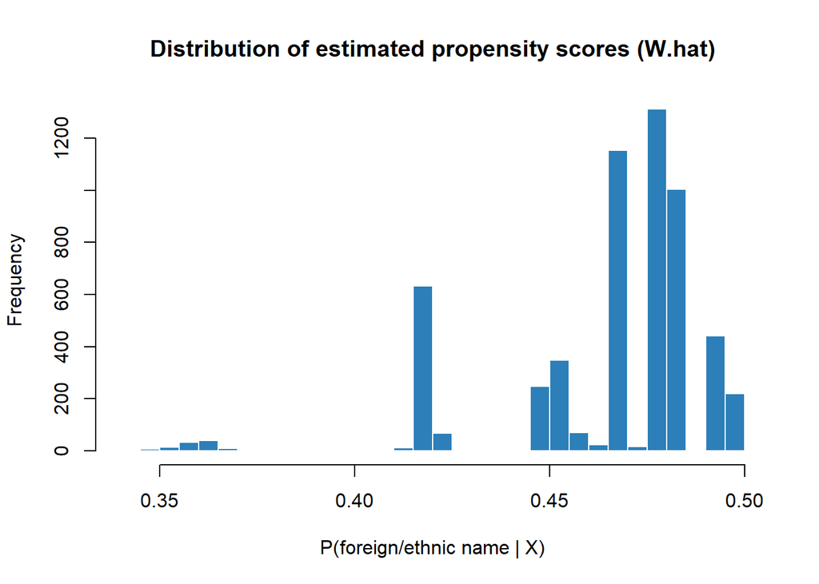

```r
hist(cf1$W.hat,
     breaks = 30,
     col = "#2c7fb8",
     border = "white",
     main = "Distribution of estimated propensity scores (W.hat)",
     xlab = "P(foreign/ethnic name | X)")
```

## Average treatment effect

```r
ate <- average_treatment_effect(cf1, target.sample = "all")
ate
```

```
##     estimate      std.err
## -0.040922674  0.006878709
```

```r
cat(sprintf(
  "**Estimated ATE:** having a foreign/ethnic-sounding name changes the callback probability by **%.3f** percentage points (SE = %.3f), on average across the analysis sample.\n",
  100 * ate["estimate"], 100 * ate["std.err"]
))
```

**Estimated ATE:** having a foreign/ethnic-sounding name changes the callback probability by **-4.092** percentage points (SE = 0.688), on average across the analysis sample.

## Variable importance

Which of the three moderators does the forest use most to split on (i.e., which one drives the most predictable heterogeneity)?

```r
vi <- variable_importance(cf1)
vi_tab <- data.frame(
  variable = colnames(forest1df_X),
  importance = as.numeric(vi)
) %>% arrange(desc(importance))

kable(vi_tab, digits = 3, caption = "Causal forest variable importance")
```

Causal forest variable importance

| variable | importance |
| --- | --- |
| extracurricular_skills | 0.370 |
| same_exp | 0.319 |
| language_skills | 0.267 |

# Causal forest 2 (ALL covariates)

1. Cluster by firmid
2. X (Covariates): ALL
3. Y: callback rate

```r
# TO ASK: MUST WE INCLUDE FALL_DATA?
df_int1 <- df_int1 %>%
  mutate(
    fall_data = as.numeric(as.character(fall_data))
  )


all_pretreat_cov <- c(
  "language_skills",
  "female",
  "ba_quality",
  "extracurricular_skills",
  "ma",
  "same_exp",
  "exp_highquality",
  "reference",
  "accreditation",
  "legal"
)


all_pretreat_cov_fall <- c(
  "language_skills",
  "female",
  "ba_quality",
  "extracurricular_skills",
  "ma",
  "same_exp",
  "exp_highquality",
  "reference",
  "accreditation",
  "legal",
  "fall_data"
)



forest2df_X <- df_int1 %>%
  select(all_of(all_pretreat_cov_fall))%>%
  as.matrix()

forest2df_treatment <- df_int1$type %>% as.matrix()
forest2df_cluster<-df_int1$firmid %>% as.matrix()
forest2df_Y<-df_int1$callback %>% as.matrix()

cf2<-causal_forest(forest2df_X,
                   forest2df_Y,
                   forest2df_treatment,
                   clusters=forest2df_cluster)
```

## Overlap / propensity check

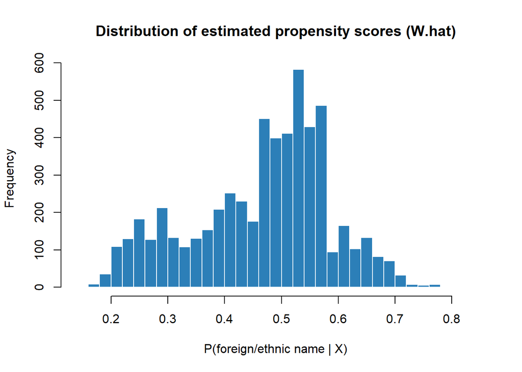

```r
hist(cf2$W.hat,
     breaks = 30,
     col = "#2c7fb8",
     border = "white",
     main = "Distribution of estimated propensity scores (W.hat)",
     xlab = "P(foreign/ethnic name | X)")
```

## Average treatment effect

```r
ate <- average_treatment_effect(cf2, target.sample = "all")
ate
```

```
##     estimate      std.err
## -0.044572412  0.007416918
```

```r
cat(sprintf(
  "**Estimated ATE:** having a foreign/ethnic-sounding name changes the callback probability by **%.3f** percentage points (SE = %.3f), on average across the analysis sample.\n",
  100 * ate["estimate"], 100 * ate["std.err"]
))
```

**Estimated ATE:** having a foreign/ethnic-sounding name changes the callback probability by **-4.457** percentage points (SE = 0.742), on average across the analysis sample.

## Variable importance

```r
vi <- variable_importance(cf2)
vi_tab <- data.frame(
  variable = colnames(forest2df_X),
  importance = as.numeric(vi)
) %>% arrange(desc(importance))

kable(vi_tab, digits = 3, caption = "Causal forest variable importance")
```

Causal forest variable importance

| variable | importance |
| --- | --- |
| female | 0.203 |
| ba_quality | 0.194 |
| extracurricular_skills | 0.136 |
| language_skills | 0.110 |
| same_exp | 0.091 |
| exp_highquality | 0.090 |
| fall_data | 0.090 |
| ma | 0.087 |
| reference | 0.000 |
| accreditation | 0.000 |
| legal | 0.000 |